# An Evaluation of Property Tax Regressivity in Jefferson County, Kentucky

Center for Municipal Finance

[figure not shown]

# 1 Introduction

The property tax is the single largest source of revenue for American local governments. Cities, counties, school districts, and special districts raise roughly $500 billion per year in property taxes, accounting for 72% of local taxes and 47% of locally raised revenue (U.S. Census Bureau 2016). Whether residents rent or own, property taxes directly or indirectly impact almost everyone.

In many cities, however, property taxes are inequitable; low-value properties face higher tax assessments, relative to their actual sale price, than do high-value properties, resulting in regressive taxation that burdens low-income residents disproportionately.

The standard approach for evaluating the quality and fairness of assessments is through a sales ratio study (International Association of Assessing Officers 2013). A property’s sales ratio is defined as the assessed value divided by the sale price. A sales ratio study evaluates the extent of regressivity in a jurisdiction, along with other aspects of assessment performance, by studying sales ratios for properties that sold within a specific time period. A system in which less expensive homes are systematically assessed at higher sales ratios than more expensive homes is *regressive*.

This report presents a basic sales ratio study for Jefferson County, Kentucky, based on data from [CoreLogic](https://www.corelogic.com/). CoreLogic collects property data from assessors (and other sources) across the country. We use data for residential properties that sold between 2007 and 2016 (the most recent year available for this jurisdiction) and are classified as arm’s-length transactions by CoreLogic. For each home that sold, we compute the sales ratio as the assessed value in place on January 1 of the sale year divided by the sale price. For more details, see the Appendix.

# 2 Sales Ratio Analysis

The relationship between assessments and sale prices is regressive if less valuable homes are assessed at higher rates (relative to the value of the home) than more valuable homes. To evaluate regressivity in assessments, Figure 2.1 presents a binned scatter plot of sales ratios against sale prices.

For this graph, property sales have been sorted into deciles (10 bins of equal size based on sale price), each representing 10% of all properties sold. Each dot represents the average sale price and average sales ratio for each respective decile of properties. This graph compares the most recent values for 2016 (solid line) with the average across all years of observation from 2007 to 2016 (dashed line). All values were adjusted for inflation to 2016 dollars to facilitate comparisons.

If sale prices are a fair indication of market value and if assessments were fair and accurate, Figure 2.1 would be a flat line indicating that sales ratios do not vary systematically according to sale price. A downward sloping line indicates that less expensive homes are over-assessed compared to more expensive homes and is evidence of regressivity.

In 2016, the most expensive homes (the top decile) were assessed at 89.3% of their value and the least expensive homes (the bottom decile) were assessed at 101.5%. In other words, the least expensive homes were assessed at **1.14 times** the rate applied to the most expensive homes. Across our sample from 2007 to 2016, the most expensive homes were assessed at 92.9% of their value and the least expensive homes were assessed at 106.4%, which is **1.15 times** the rate applied to the most expensive homes.

### Figure 2.1

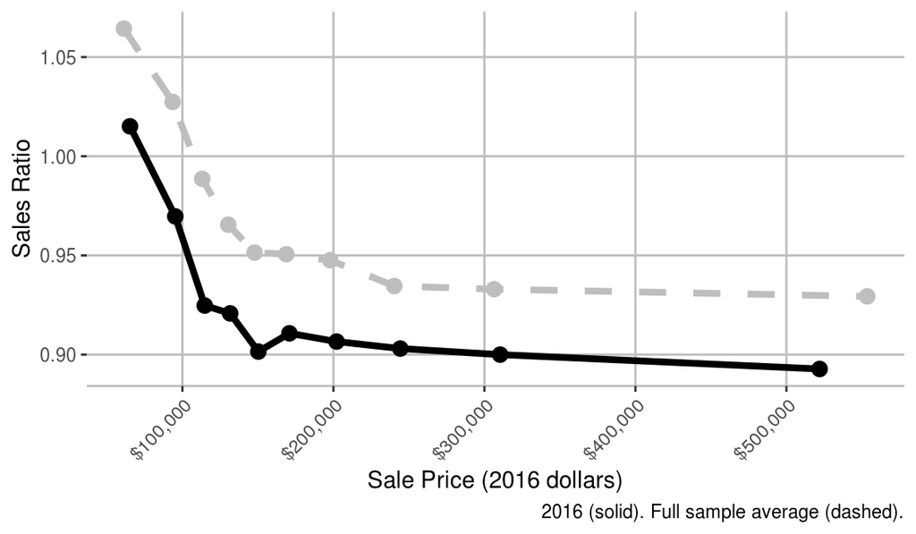

Figure 2.2 shows the share of properties in each decile that were overassessed or underassessed. relative to the median rate of assessment. That is, a property is classified as overassessed if its sales ratio is above the median sales ratio for the jurisdiction, and classified as underassessed if its sales ratio is below the median. If errors were made randomly, each decile would have 50% of properties overassessed and 50% underassessed. When lower value homes are more likely to be overassessed than higher value homes, it is evidence of regressivity. In Jefferson County, Kentucky, **62%** of the lowest value homes are overassessed and **37%** of the highest value homes are overassessed.

### Figure 2.2

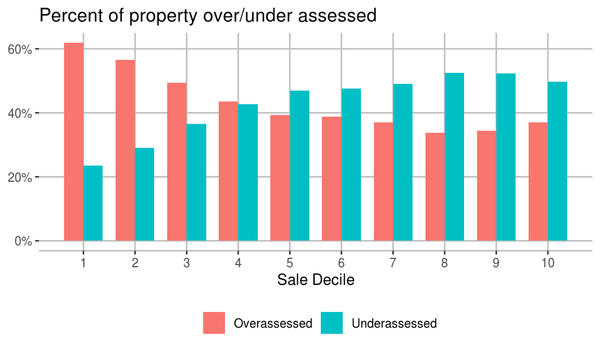

# 3 Effective Tax Rates

Assessed values are the basis on which taxes are calculated, meaning that inequities in assessments will be transmitted into inequities in tax rates. In this section, we evaluate effective tax rates – a property’s tax bill divided by its sale price – according to sale price.

Importantly, the effective tax rate is the actual tax rate paid inclusive of exemptions or other tax breaks. Often, because exemptions are more likely to target low-valued properties, they may offset some of the increased taxation resulting from over-assessment. In other words, tax rates will often be somewhat less regressive than assessments. Tax rates also will vary widely based on municipal and school district boundaries. This section analyzes tax rates across the entire county. A brief analysis by school district, which roughly approximates a single taxing district, is also presented in the Appendix.

Consistent with Figure 2.1, in 2016, the most expensive homes (the top decile) had an effective tax rate of 0.95%, while the rate for the least expensive homes (bottom decile) was 1.10%, which is **1.16 times** the rate applied to the most expensive homes. Across our sample from 2007 to 2016, the most expensive homes had an effective tax rate of 0.97% of their value and the least expensive homes had an effective tax rate of 1.18%, which is **1.21 times** the rate applied to the most expensive homes.

### Figure 3.1

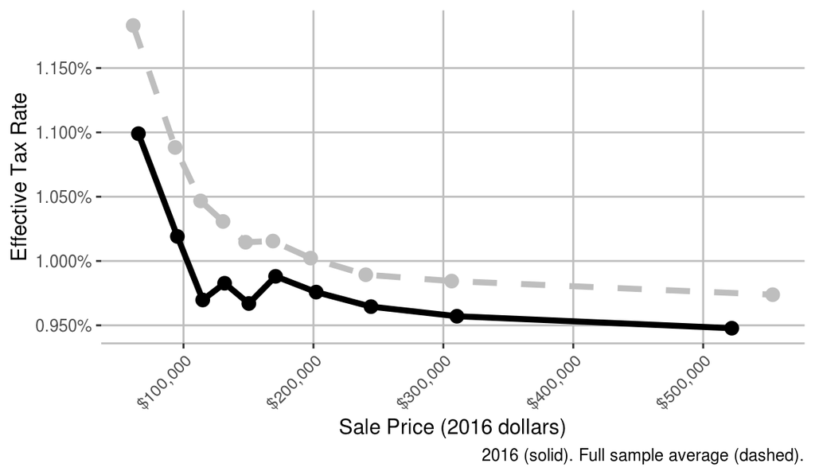

### Table 3.1

Table 3.1 presents a simple analysis of effective tax rate by sale decile (where sale decile 1 consists of the most inexpensive homes in this jurisdiction and 10 the most expensive). A property’s “fair” tax bill is the bill that would have been charged if the property was taxed at the average rate, and the “shift” is the difference between the fair bill and the actual bill. In 2016, the average effective tax rate in Jefferson County, Kentucky was 0.99%.

Tax Rate by Sale Decile

| Tax Year | Sale Decile | Effective Tax Rate | Average Sale | Average Tax Bill | Fair Tax Bill | Average Shift |
| --- | --- | --- | --- | --- | --- | --- |
| 2016 | 1 | 1.10% | $65,275 | $708.29 | $644.28 | $64.02 |
| 2016 | 2 | 1.02% | $95,276 | $970.70 | $940.40 | $30.31 |
| 2016 | 3 | 0.97% | $114,787 | $1,112.75 | $1,132.97 | -$20.23 |
| 2016 | 4 | 0.98% | $131,614 | $1,293.28 | $1,299.06 | -$5.78 |
| 2016 | 5 | 0.97% | $150,274 | $1,453.34 | $1,483.23 | -$29.90 |
| 2016 | 6 | 0.99% | $170,860 | $1,687.59 | $1,686.42 | $1.17 |
| 2016 | 7 | 0.98% | $202,083 | $1,972.31 | $1,994.60 | -$22.29 |
| 2016 | 8 | 0.96% | $244,303 | $2,356.67 | $2,411.33 | -$54.65 |
| 2016 | 9 | 0.96% | $310,437 | $2,971.88 | $3,064.08 | -$92.20 |
| 2016 | 10 | 0.95% | $522,013 | $4,935.20 | $5,152.38 | -$217.18 |

For example, in 2016, the average property in the bottom decile sold for a price of $65,275 and had a tax bill of $708.29. If this property was taxed at the average rate of all other properties, its fair bill would be $644.28, meaning that the homeowner **overpaid by $64.02, or 9.9% above** the fair tax. Correspondingly, the average property in the top decile sold for $522,013 and had a tax bill of $4,935.20. If this property was taxed at the average rate of all other property, its fair bill would be $5,152.38, meaning that the homeowner **underpaid by $217.18, or 4.2% below** the fair tax.

# 4 Industry Standards

Sections 2 and 3 provide graphical evidence of regressivity in property assessments and taxes, but they do not provide a statistical evaluation. In this section, we report several standard statistics used in the evaluation of assessment quality.

The International Association of Assessing Officers (IAAO) defines standards for assessments including standards for uniformity and regressivity (International Association of Assessing Officers 2013). A detailed overview and definition of each measure can be found in the Appendix.

## 4.1 Coefficient of Dispersion (COD)

The COD is a measure of assessment uniformity, or horizontal equity. It is the average absolute percentage difference from the median sales ratio. For instance, a COD of 10 means that properties have ratios that on average deviate by 10 percent from the median ratio. The IAAO specifies that the acceptable range for COD is below 15, which is shaded in Figure 4.1. For 2016, the COD in Jefferson County, Kentucky was 12. Year-to-year changes in COD can also reveal changes assessment accuracy. In this case, assessments **meet** the IAAO standard for uniformity and are **relatively unchanged** over the last two years.

### Figure 4.1

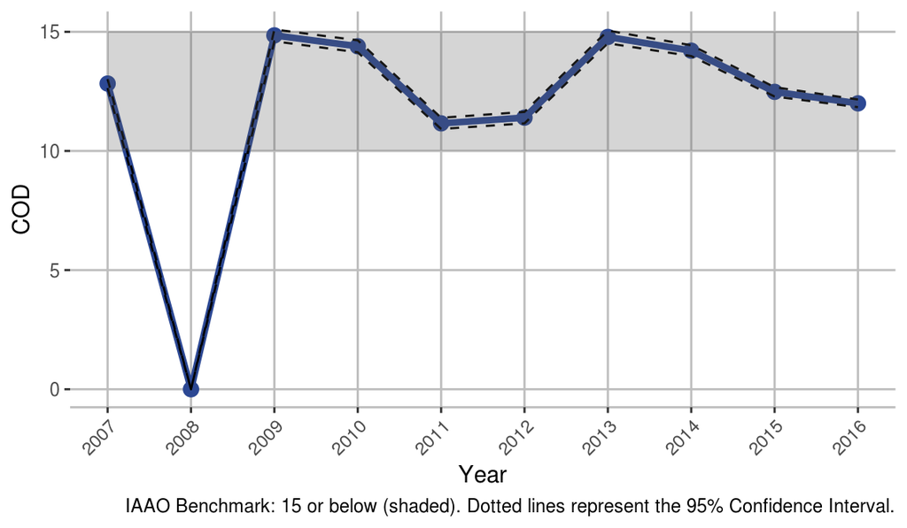

## 4.2 Price-Related Differential (PRD)

The PRD is a measure of regressivity, or vertical equity. A PRD of 1 indicates that homes are assessed at the same rate regardless of their sale price. A PRD greater than 1 indicates that less expensive homes are assessed at higher rates than more expensive homes, while a PRD less than 1 represents the opposite situation. The IAAO specifies that the acceptable range of PRD is .98 to 1.03, which is depicted as the shaded region of Figure 4.2. In 2016, the PRD in Jefferson County, Kentucky, was 1.016 which **meets** the IAAO standard for vertical equity. PRD values are **relatively unchanged** over the last two years.

### Figure 4.2

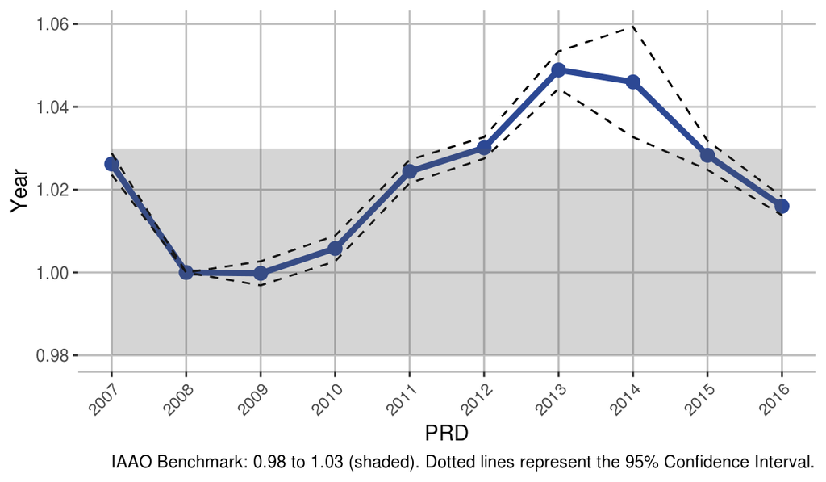

## 4.3 Coefficient of Price-Related Bias (PRB)

The PRB is another quantitative measure of regressivity (vertical equity) which is an alternative to the PRD. PRB is a measure of how much assessed values change as a property’s market value increases. The IAAO specifies that the acceptable range for PRB is between -0.05 and 0.05, which is depicted as the shaded region in the Figure 4.3. In 2016, the PRB in Jefferson County, Kentucky was -0.014 which indicates that sales ratios decrease by 1.4% when home values double. This **meets** the IAAO standard. PRB values have been relatively **relatively unchanged** over the last two years.

### Figure 4.3

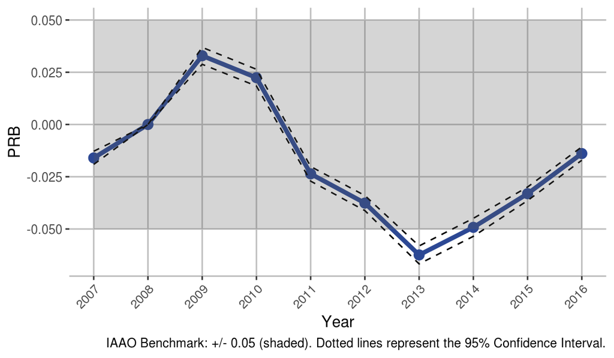

# 5 Who is Over-Assessed?

By placing homes geographically within individual census tracts (“geocoding”), we are able to explore how assessments differ across geography. We are also able to correlate assessment rates with census demographics on the tract level.

## 5.1 Geographic Variation

In most jurisdictions, properties of different values are not randomly distributed but rather spatially clustered. If so, then regressivity in assessments will result in some neighborhoods of the jurisdiction being over-assessed and others under-assessed. The two maps below show the spatial distribution of sales ratios (Figure 5.1) and effective tax rates (Figure 5.2), respectively.

### Figure 5.1

[interactive chart not shown]

### Figure 5.2

Note that tax rates may vary across jurisdictions for reasons unrelated to assessment quality.

[interactive chart not shown]

## 5.2 Demographic Variation

When there are correlations between property values and demographics, assessment regressivity will result in differential taxation by demographics. This section presents a basic demographic profile of Jefferson County, Kentucky, based on the 2018 American Community Survey produced by the U.S. Census Bureau (Walker 2019a). Next is an analysis of the correlations between census demographics at the tract level and sales ratios and tax rates. Essentially, these correlations reveal whether properties in different sorts of neighborhoods experience different levels of assessment and taxation. It is important to emphasize that we do not have data on the demographics of individual property owners and so these tract-level demographic correlations do not necessarily imply that individual owners with different demographics are assessed or taxed differentially.

### Table 5.2.1: A Demographic Profile of Jefferson County, Kentucky

| Total Population | 764,378 |
| --- | --- |
| Percent Non-White | 31% |
| Percent in Poverty | 15% |
| Percent Homeowners | 62% |
| Percent with Bachelor (or higher) | 32% |
| Per Capita Income | $31,039 |
| Median Age | 38 |
| Median Home Value | $159,000 |
| Median Home Value (State Rank) | 8th |

### 5.2.1 Demographic Correlates: Sales Ratios

Table 5.2.2 presents results from an analysis in which sales ratios are regressed against census tract demographics. Each row of the table represents the coefficient from a different bivariate regression of sales ratios against the census variable in question.

### Table 5.2.2

An example interpretation of this table; a 1% increase in the percentage of individuals with a high school education is correlated with a -0.10% decrease in sales ratio.

Census Tract Characteristics Regressed on Mean sales ratio

| Variable | Coefficient | P Value | Significance |
| --- | --- | --- | --- |
| Non-Hispanic White Population (Percentage Points) | -0.03% | 0.00 | Significant |
| Population in Poverty (Percentage Points) | 0.00% | 0.86 | Not Significant |
| Share of Homes Vacant (Percentage Points) | -0.04% | 0.26 | Not Significant |
| Share of Homeowners (Percentage Points) | 0.01% | 0.27 | Not Significant |
| Share of Single Unit Homes (Percentage Points) | 0.02% | 0.12 | Not Significant |
| Share in Same Home as Last Year (Percentage Points) | 0.12% | 0.00 | Significant |
| High School Education or Higher (Percentage Points) | -0.10% | 0.00 | Significant |
| College Education or Higher (Percentage Points) | -0.07% | 0.00 | Significant |
| Per Capita Income ($1000s) | -0.07% | 0.00 | Significant |
| Median Household Income ($1000s) | -0.02% | 0.10 | Not Significant |
| Median Age (Years) | -0.01% | 0.77 | Not Significant |
| Median Home Value ($1000s) | -0.01% | 0.00 | Significant |

Figure 5.2.1 presents binned scatterplots of the average assessment rate by census tract for selected demographic variables.

### Figure 5.2.1

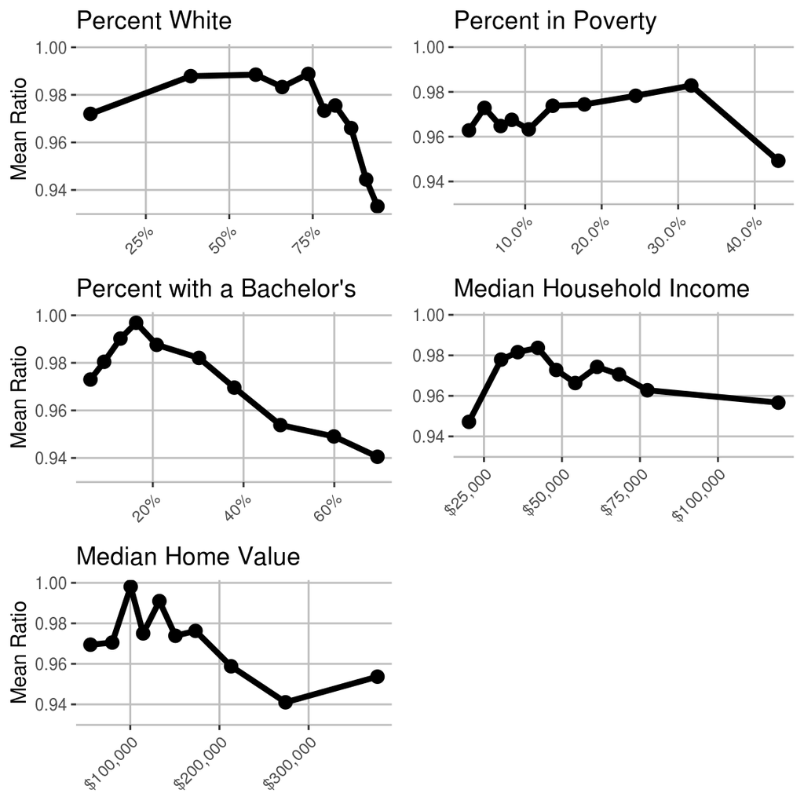

### 5.2.2 Demographic Correlates: Effective Tax Rates

Table 5.2.3 shows relationships between effective tax rates and census demographics at the tract level. Each row of the table represents the coefficient from a different bivariate regression of the effective tax rate against the census variable in question.

### Table 5.2.3

Census Tract Characteristics Regressed on Mean Tax Rate

| Variable | Coefficient | P Value | Significance |
| --- | --- | --- | --- |
| Non-Hispanic White Population (Percentage Points) | -0.19% | 0 | Significant |
| Population in Poverty (Percentage Points) | 0.55% | 0 | Significant |
| Share of Homes Vacant (Percentage Points) | 0.80% | 0 | Significant |
| Share of Homeowners (Percentage Points) | -0.30% | 0 | Significant |
| Share of Single Unit Homes (Percentage Points) | -0.14% | 0 | Significant |
| Share in Same Home as Last Year (Percentage Points) | -0.50% | 0 | Significant |
| High School Education or Higher (Percentage Points) | -0.56% | 0 | Significant |
| College Education or Higher (Percentage Points) | -0.13% | 0 | Significant |
| Per Capita Income ($1000s) | -0.29% | 0 | Significant |
| Median Household Income ($1000s) | -0.22% | 0 | Significant |
| Median Age (Years) | -0.85% | 0 | Significant |
| Median Home Value ($1000s) | -0.04% | 0 | Significant |

An example interpretation of this table; a 1% increase in the percentage of individuals with a high school education is correlated with a -0.56% decrease in effective tax rate.

Figure 5.2.2 presents the average tax rate by census tract for selected demographic variables.

### Figure 5.2.2

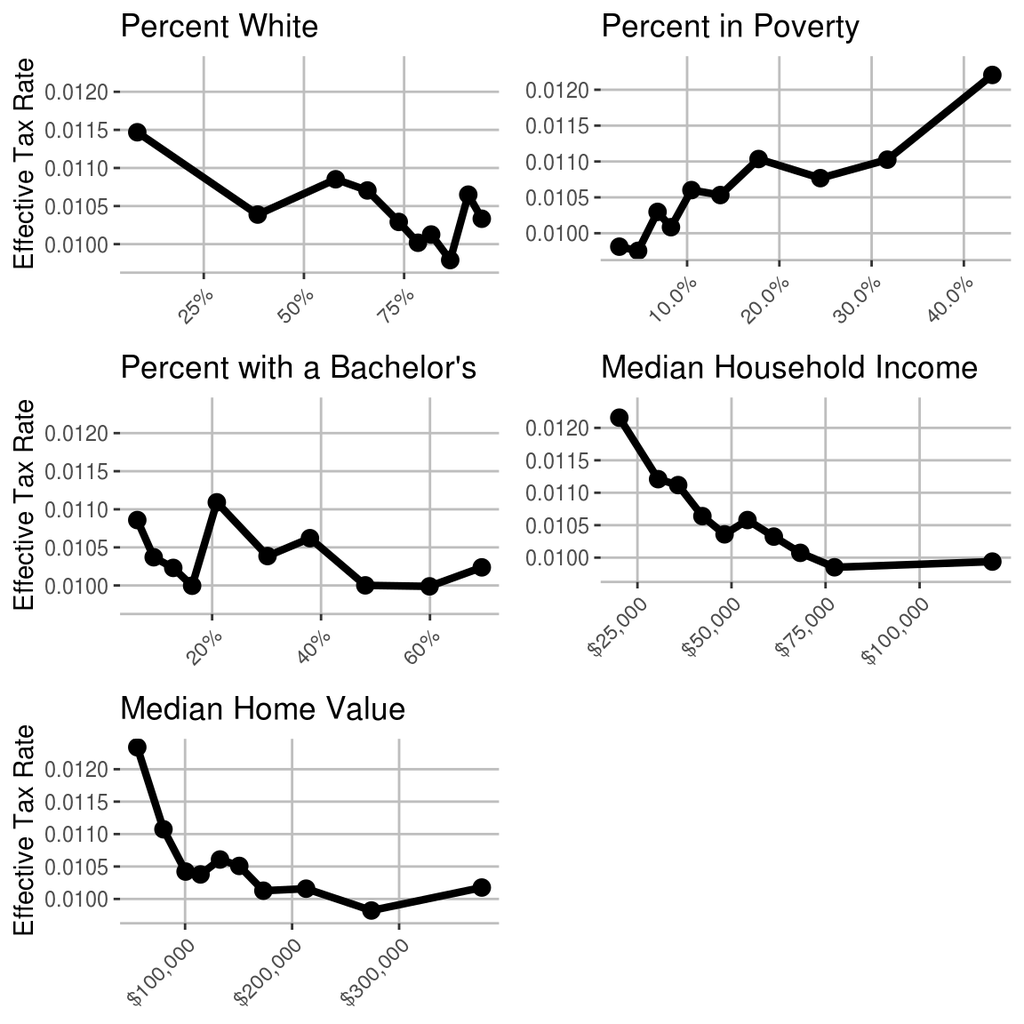

# 6 Comparison with Other Jurisdictions

Figure 6.1, Figure 6.2, and Table 6.1 compare this jurisdiction to the rest of the nation. Higher values (to the right side) are more regressive.

### Figure 6.1

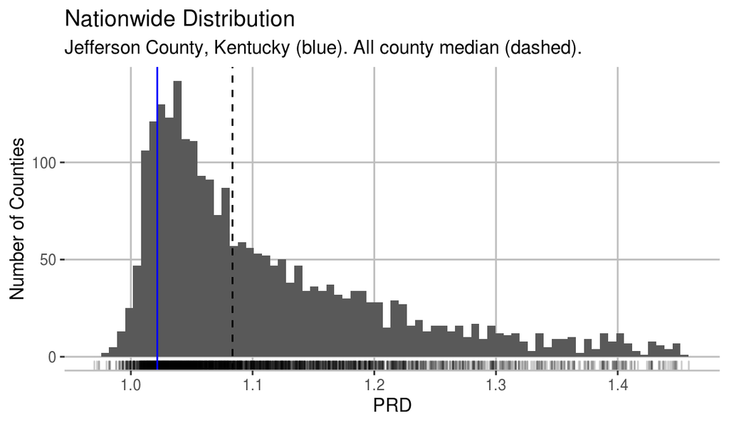

### Figure 6.2

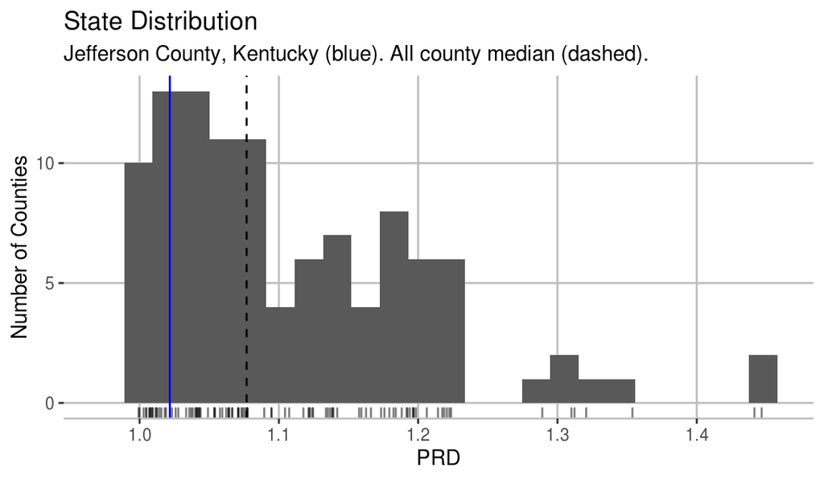

### Table 6.1

National and State Ranks

| 90 to 10 ratio | 0.874 |
| --- | --- |
| 90 to 10 ratio National Rank | 2293/2633 |
| 90 to 10 ratio State Rank | 83/108 |
| 80 to 20 ratio | 0.908 |
| 80 to 20 ratio National Rank | 2099/2633 |
| 80 to 20 ratio State Rank | 88/108 |
| PRD | 1.022 |
| PRD National Rank | 2298/2633 |
| PRD State Rank | 89.5/108 |
| Number of Unranked Counties Nationwide | 492 |
| Number of Unranked Counties Statewide | 12 |

# 7 Appendices

Here detailed information on our analysis is presented alongside reference information.

- Click here to learn more about the IAAO Standards
- Click here to see how the IAAO Statistics change over time
- Click here to see how Figure 2.1 changes over time
- Click here to learn how we check that our results are not due to randomness
- Click here to see how tax rates differ across every school district with sufficient data
- Click here to see how alternative measures of regressivity evaluated for Jefferson County, Kentucky

## 7.1 IAAO Standards

The International Association of Assessing Officers (IAAO) defines standards for assessments including standards for uniformity and vertical equity (International Association of Assessing Officers 2013). Uniform assessments assess similar properties with as little variability as possible. Vertically equitable assessments assess properties at similar rates regardless of a property’s value. The three main standards are:

- Coefficient of Dispersion (COD) is a measure of uniformity based on the average deviation from the median ratio. For example, given a COD of 15, a property worth $100,000 has a 50% chance to be assessed between $85,000 and $115,000.
- Price-Related Differential (PRD) is a measure of vertical equity calculated by dividing mean ratios by weighted mean ratios. For example, assume a jurisdiction contains two homes, one worth $100,000 assessed at 12% and one worth $1,000,000 assessed at 8% of the fair market value. The mean ratio would be 10% ($\frac{12\% + 8\%}{2}$) while the weighed mean ratio would be 8.4% ($\frac{0.12*\$100,000 + 0.08*\$1,000,000}{\$1,100,000}$). The resulting PRD would be $\frac{10\%}{8.4\%} = 1.2$.
- Coefficient of Price-Related Bias (PRB) measures the change in sales ratios relative to a percentage change in property values. For example, a PRB of 0.031 indicates that sales ratios increase by 3.1% when the home value doubles.

### Table 7.1.1

IAAO Standards for Single Family Residential Properties

| Parameter | Standard Minimum | Standard Maximum |
| --- | --- | --- |
| COD | 5.00 | 15.00 |
| PRD | 0.98 | 1.03 |
| PRB | -0.05 | 0.05 |

## 7.2 IAAO Statistics by Year

The following is a detailed breakdown by year of our estimates of IAAO standards and their bootstrapped confidence intervals. These estimates form the basis of our COD, PRD, and PRB plots.

### Table 7.2.1

Calculated Values for COD, PRD, and PRB

| Tax Year | Arms Length Sales | Average Sale Price | COD | PRD | PRB |
| --- | --- | --- | --- | --- | --- |
| 2007 | 15701 | $134,500 | 12.8278 ± 0.188 | 1.0262 ± 0.003 | -0.016 ± 0.003 |
| 2008 | 10416 | $135,000 | 0 ± 0 | 1 ± 0 | 0 ± 0 |
| 2009 | 12235 | $135,500 | 14.8507 ± 0.247 | 0.9998 ± 0.003 | 0.0329 ± 0.004 |
| 2010 | 11494 | $140,110 | 14.3919 ± 0.252 | 1.0058 ± 0.003 | 0.0224 ± 0.004 |
| 2011 | 10799 | $140,000 | 11.158 ± 0.235 | 1.0244 ± 0.003 | -0.0236 ± 0.003 |
| 2012 | 11237 | $146,000 | 11.3977 ± 0.24 | 1.0301 ± 0.003 | -0.0376 ± 0.004 |
| 2013 | 11033 | $150,000 | 14.7839 ± 0.266 | 1.0489 ± 0.004 | -0.0624 ± 0.004 |
| 2014 | 10639 | $150,000 | 14.2085 ± 0.226 | 1.046 ± 0.013 | -0.0492 ± 0.004 |
| 2015 | 12558 | $154,000 | 12.4804 ± 0.196 | 1.0283 ± 0.004 | -0.0331 ± 0.003 |
| 2016 | 13501 | $160,000 | 11.9976 ± 0.16 | 1.016 ± 0.002 | -0.0139 ± 0.003 |

## 7.3 Sales Ratio by Decile by Year

The following Figure 7.3.1 replicates Figure 2.1 from Sales Ratio Analysis. For each panel of the Figure 7.3.1, the current year is highlighted in blue and other years are in gray.

### Figure 7.3.1

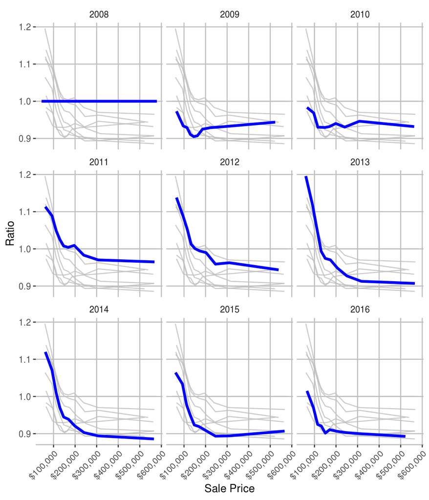

Table 7.3.1 shows the data underling the Figure 2.1 from Sales Ratio Analysis.

### Table 7.3.1

Sales Ratio by Sale Decile and Year

| Sale Year | Sale Decile | Average Sale Price | Mean Ratio | Median Ratio |
| --- | --- | --- | --- | --- |
| 2016 | 1 | $65,275 | 1.0151 | 1.0102 |
| 2016 | 2 | $95,276 | 0.9697 | 0.9630 |
| 2016 | 3 | $114,787 | 0.9247 | 0.9243 |
| 2016 | 4 | $131,614 | 0.9208 | 0.9200 |
| 2016 | 5 | $150,274 | 0.9015 | 0.9015 |
| 2016 | 6 | $170,860 | 0.9107 | 0.9086 |
| 2016 | 7 | $202,083 | 0.9066 | 0.9089 |
| 2016 | 8 | $244,303 | 0.9030 | 0.9103 |
| 2016 | 9 | $310,437 | 0.9000 | 0.9066 |
| 2016 | 10 | $522,013 | 0.8927 | 0.9125 |

Sales Ratio by Sale Decile (all years)

| Sale Decile | Average Sale Price | Mean Ratio | Median Ratio |
| --- | --- | --- | --- |
| 1 | $61,248 | 1.0644 | 1.0000 |
| 2 | $93,537 | 1.0274 | 1.0000 |
| 3 | $113,136 | 0.9886 | 1.0000 |
| 4 | $130,375 | 0.9655 | 0.9928 |
| 5 | $147,801 | 0.9514 | 0.9760 |
| 6 | $168,813 | 0.9506 | 0.9735 |
| 7 | $197,856 | 0.9476 | 0.9682 |
| 8 | $240,291 | 0.9346 | 0.9556 |
| 9 | $306,397 | 0.9330 | 0.9555 |
| 10 | $553,510 | 0.9294 | 0.9645 |

## 7.4 Measurement Error and Spurious Regressivity

One limitation of sales ratio studies is that a property’s sale price may be an imperfect indication of its true market value. Given inevitable random factors in the sale of any individual property, the final price may include some “noise.” If properties are spatially cluttered, this will introduce measurement error into the analysis, which could lead to the appearance of regressivity when there is none. For instance, consider two hypothetical homes that are identical and each worth $100,000. If both homes went up for sale at the same time, one home might fetch a price of $105,000, say if the seller were a particularly savvy negotiator, while the other home might garner only $95,000, say if the buyer were a particularly savvy negotiator. If the assessor appropriately valued both homes at $100,000, a sales ratio analysis would indicate regressivity (the higher-priced home is under-assessed and the lower-priced home would be over-assessed, relative to the sale price). While there is no reliable correction for measurement error of this kind, as long as the extent of measurement error is small, relative to the price, the extent of bias will also be small.

We use Monte Carlo simulations to estimate the extent of measurement error that would need to exist for any of our tests to falsely show regressivity due to measurement error. We compare our results with thousands of simulated scenarios to determine the likelihood that our results would be reproduced in the absence of regressivity.

The simulations are conducted as follows. First, using the same data set that was used for the main analysis, we construct a simulated sale price for each property that is set equal to the actual assessed value. In this scenario where simulated sale prices always equal assessed value, the assessments will appear to be perfect according to all of our metrics and there will be no regressivity. We then “jitter” the simulated sale prices by adding random noise drawn from a normal distribution with a mean of zero and a standard deviation of k percent. While we think that measurement error on the order of only a few percentage points is plausible in real data, we consider values of k ranging from 1 to 25. To be concrete, when k is equal to one percent, the simulated sale price is set equal to the assessed value multiplied by (1 plus a random shock drawn from a normal distribution with a mean of zero and a standard deviation of .01). The shock is drawn independently for each property in the data set. For each value of k, we run 100 simulations and record the value of each metric computed in each simulation. The mean value of each metric across the 100 simulations is reported for each value of k.

Intuitively, this exercise shows how much spurious regressivity would exist if assessed values were accurate on average but sale prices contained random noise of a given value, k. We then compare the actual value of the regressivity metrics from the real data with the values from the simulated data to recover an estimate of the amount of noise that would be necessary to produce the observed regressivity statistic if there were in fact no bias in assessments.

### Figure 7.4.1

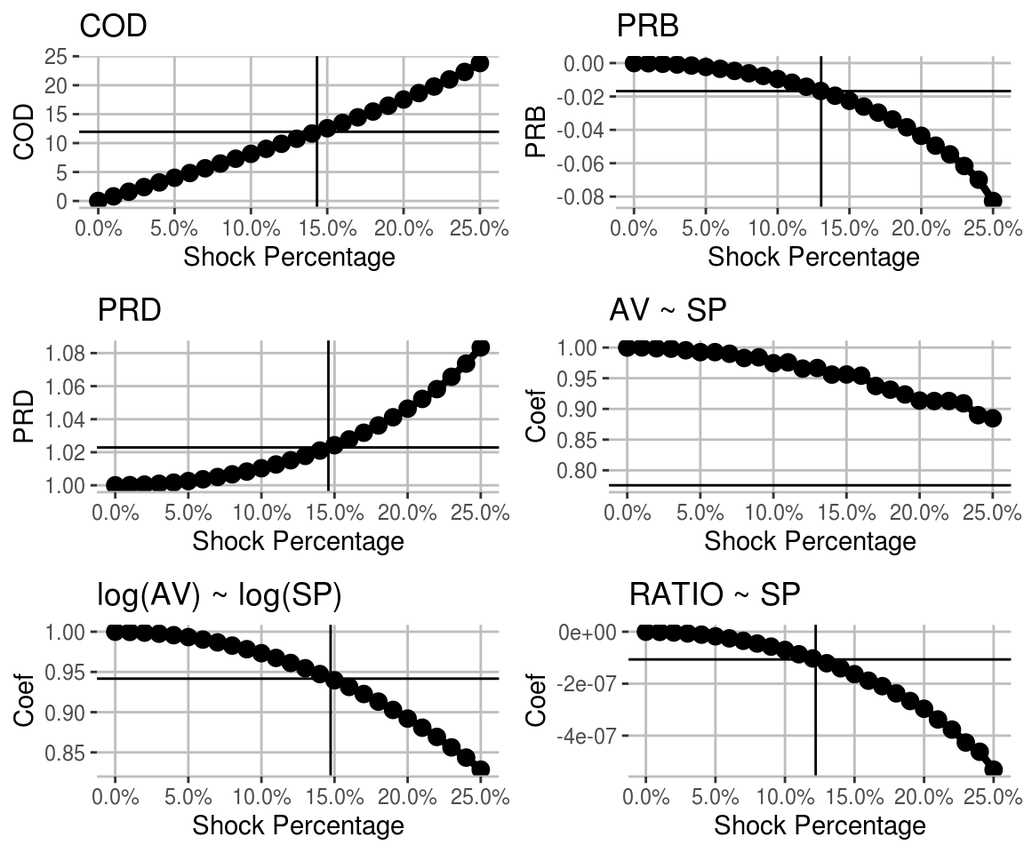

## 7.5 Effective Tax Rate by School District

In many jurisdictions, the tax rate varies based on the overlap of taxing districts, such as municipality, school district, or special district. The final determination of tax bills varies widely place-to-place, but the school district often accounts for the largest component of property taxes. This section presents estimates for the largest school district in this county (contained within one city) and summary information on all unified (K-12) school districts in which sufficient property information is available.

### 7.5.1 Jefferson County School District

### Figure 7.5.1

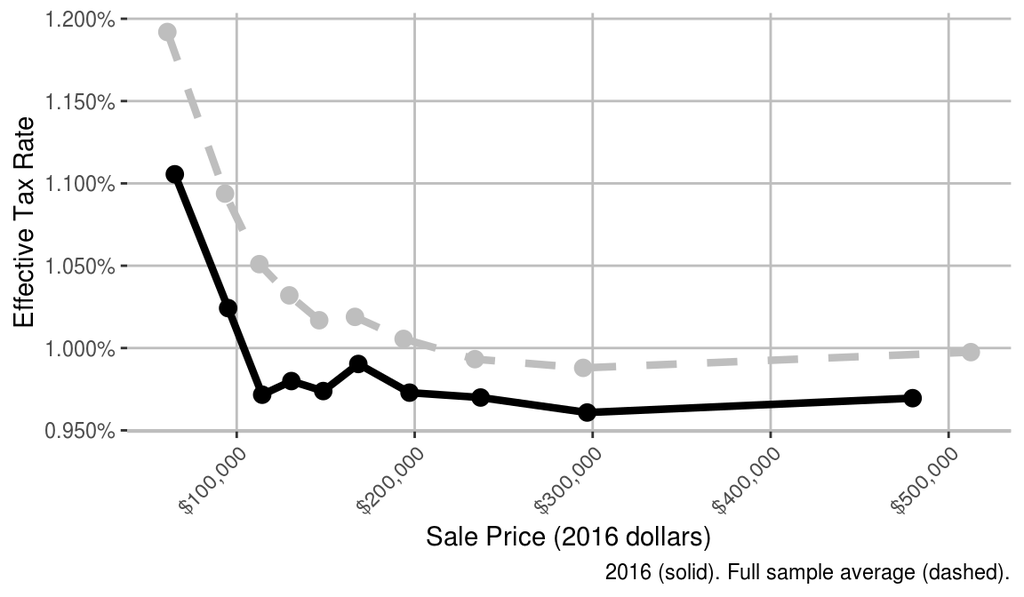

In 2016, the most expensive homes (the top decile) had an effective tax rate of 0.97%, while the rate for the least expensive homes (bottom decile) was 1.11%, which is **1.14 times** the rate applied to the most expensive homes. Across our sample from 2007 to 2016, the most expensive homes had an effective tax rate of 1.00% of their value and the least expensive homes had an effective tax rate of 1.19%, which is **1.19 times** the rate applied to the most expensive homes.

### 7.5.2 All Districts

### Table 7.5.1

Tax Rate by School District

| District | City | Number of Sales | Effective Tax Rate | Average Sale | Average Tax Bill | Bottom Decile Tax Rate | Top Decile Tax Rate | Bottom Decile Sale Price | Top Decile Sale Price |
| --- | --- | --- | --- | --- | --- | --- | --- | --- | --- |
| Jefferson County School District | FAIRDALE | 816 | 0.97% | $115,690 | $1,100.21 | 1.13% | 0.91% | $59,349.66 | $220,936 |
| Jefferson County School District | LOUISVILLE | 97001 | 1.04% | $194,418 | $1,972.75 | 1.20% | 1.00% | $60,983.72 | $511,715 |
| Jefferson County School District | PROSPECT | 2403 | 0.99% | $415,925 | $4,062.23 | 1.04% | 0.97% | $99,343.00 | $1,046,496 |
| Jefferson County School District | SAINT MATTHEWS | 549 | 0.95% | $183,175 | $1,706.79 | 0.99% | 0.85% | $65,532.22 | $332,213 |

## 7.6 Regression-Based Estimates of Regressivity

Aside from the standard PRD and PRB tests recommended by the IAAO, several alternative metrics have been proposed by academic researchers (Hodge et al. 2017). Table 7.6.1 presents estimates of the most commonly used models.

Model (1) shows a regression of assessed value (AV) against sale price. The coefficient on sale price should equal the jurisdiction’s legally mandated assessment rate (i.e., for each dollar of sale price, the assessed value should increase by the mandated assessment rate). In a jurisdiction where the assessment rate is 100%, the coefficient should be 1. A coefficient smaller than the assessment ratio indicates regressivity.

Model (2) shows a regression of the log of assessed value against the log of sale price, which estimates the elasticity of assessed values with respect to sale price. In the absence of regressivity, this coefficient should be 1. A value less than 1 indicates regressivity.

Model (3) shows a regression of sales ratios against sale prices. In the absence of regressivity, this coefficient should be zero. A negative coefficient is an indication of regressivity.

### Table 7.6.1

|  | Dependent Variable |  |  |
| --- | --- | --- | --- |
|  | AV | log(AV) | Sales_Ratio |
|  | (1) | (2) | (3) |
| SALE_PRICE | 0.78*** |  | -0.0000*** |
|  | (0.001) |  | (0.00) |
| log(SALE_PRICE) |  | 0.94*** |  |
|  |  | (0.001) |  |
| Constant | 32,162.08*** | 0.65*** | 0.99*** |
|  | (210.28) | (0.01) | (0.001) |
| Observations | 103,856 | 103,856 | 103,856 |
| R<sup>2</sup> | 0.91 | 0.92 | 0.02 |
| Adjusted R<sup>2</sup> | 0.91 | 0.92 | 0.02 |
| *Note:* | p<0.1; p<0.05; p<0.01 |  |  |

# Citations

Cheng, Joe, Bhaskar Karambelkar, and Yihui Xie. 2018. *Leaflet: Create Interactive Web Maps with the Javascript ’Leaflet’ Library*. https://CRAN.R-project.org/package=leaflet.

Cook County Assessor’s Office. 2019. *Open Code Base*. https://gitlab.com/ccao-data-science---modeling.

Hadley Wickham and Winston Chang, et. al. 2019. *Ggplot2: Create Elegant Data Visualisations Using the Grammar of Graphics*. https://CRAN.R-project.org/package=ggplot2.

Hlavac, Marek. 2018. *Stargazer: Well-Formatted Regression and Summary Statistics Tables*. https://CRAN.R-project.org/package=stargazer.

Hodge, Timothy R., Daniel P. McMillen, Gary Sands, and Mark Skidmore. 2017. “Assessment Inequity in a Declining Housing Market: The Case of Detroit.” *Real Estate Economics* 45 (2): 237–58. https://doi.org/10.1111/1540-6229.12126.

International Association of Assessing Officers. 2013. *Standard on Ratio Studies*. https://www.iaao.org/media/standards/Standard_on_Ratio_Studies.pdf.

JJ Allaire and Yihui Xie, et. al. 2019. *Rmarkdown: Dynamic Documents for R*. https://CRAN.R-project.org/package=rmarkdown.

Pebesma, Edzer. 2019. *Sf: Simple Features for R*. https://CRAN.R-project.org/package=sf.

U.S. Census Bureau. 2016. *2016 Annual Surveys of State and Local Government Finances*. https://www.census.gov/data/datasets/2016/econ/local/public-use-datasets.html.

Walker, Kyle. 2019a. *Tidycensus: Load Us Census Boundary and Attribute Data as ’Tidyverse’ and ’Sf’-Ready Data Frames*. https://CRAN.R-project.org/package=tidycensus.

———. 2019b. *Tigris: Load Census Tiger/Line Shapefiles*. https://CRAN.R-project.org/package=tigris.